# Course Notes 1

January 12, 2016

## R scripts

## R scripts

If you are writing code you think you will use later, write it in an R script file rather than using the console.

- Open a new script file in RStudio: `File` -> `New File` -> `R Script`.
- To run code from an R script file in RStudio, you can use the `Run` button (or `Command-R`). It will run whatever's on your cursor line or whatever's highlighted.
- To run the whole script, use `source`.
- Save scripts using the extension `.R`

## R object types

## R's most basic object types

The two most basic types of objects for data in R are **vectors** (1D) and **dataframes** (2D).

## Vectors

- A vector is a string of values.
- All values must be of the same class (i.e., all numbers, all characters, all dates)
- You can use `c()` to join values together to create a vector
- The *length* of the vector is how many values it has in it

For example:

```r
fibonacci <- c(1, 1, 2, 3, 5)
fibonacci
```

```
## [1] 1 1 2 3 5
```

```r
length(fibonacci)
```

```
## [1] 5
```

## Vectors

An example using characters instead of numbers:

```r
one_to_five <- c("one", "two", "three", "four", "five")
one_to_five
```

```
## [1] "one"   "two"   "three" "four"  "five"
```

If you mix classes, it will default to most generic:

```r
mixed_classes <- c(1, 3, "five")
mixed_classes
```

```
## [1] "1"    "3"    "five"
```

## Vectors

You can pull out certain values by using indexing (`[...]`) to identify the locations you want to get

```r
fibonacci[2] # Get the second value
```

```
## [1] 1
```

```r
fibonacci[c(1, 5)] # Get first and fifth values
```

```
## [1] 1 5
```

```r
fibonacci[1:3] # Get the first three values
```

```
## [1] 1 1 2
```

## Dataframes

A dataframe is one or more vectors of the same length stuck together side-by-side. It is the closest R has to what you'd get with an Excel spreadsheet.

You can create dataframes using the `data.frame()` function. However, most often you will create a dataframe by reading in data from a file using something like `read.csv()`.

## Dataframes

For example, to create a dataframe from vectors you already have saved as R objects:

```r
fibonacci_seq <- data.frame(num_in_seq = one_to_five,
                            fibonacci_num = fibonacci)
fibonacci_seq
```

```
##   num_in_seq fibonacci_num
## 1        one             1
## 2        two             1
## 3      three             2
## 4       four             3
## 5       five             5
```

## Dataframes

The format for using `data.frame()` is:

```r
## Note: Generic code-- this will not work
[name of object] <- data.frame([1st column name] = [1st column content],
                               [2nd column name] = [2nd column content])
```

## Dataframes

You can use indexing (`[..., ...]`) for dataframes, too, but now they'll have two dimensions (rows, then columns). Put the rows you want before the comma, the columns after. If you want all of something, leave the designated spot blank. For example:

```r
fibonacci_seq[1:2, 2] # First two rows, second column
```

```
## [1] 1 1
```

```r
fibonacci_seq[5, ] # Last row, all columns
```

```
##   num_in_seq fibonacci_num
## 5       five             5
```

## Dataframes

Usually, instead of creating a dataframe from vectors, you'll read one in from data on an outside file. For example, to read in a dataset from a CSV file called `daily_show_guests.csv`:

```r
daily_show <- read.csv("data/daily_show_guests.csv",
                       header = TRUE,
                       skip = 4)
daily_show[1:2, ]
```

```
##   YEAR GoogleKnowlege_Occupation    Show  Group  Raw_Guest_List
## 1 1999                     actor 1/11/99 Acting  Michael J. Fox
## 2 1999                  Comedian 1/12/99 Comedy Sandra Bernhard
```

## Dataframes

You can use the functions `dim()`, `nrow()`, and `ncol` to figure out the dimensions (number of rows and columns) of a dataframe:

```r
dim(daily_show)
```

```
## [1] 2693    5
```

```r
nrow(daily_show)
```

```
## [1] 2693
```

```r
ncol(daily_show)
```

```
## [1] 5
```

## Basics of using functions

## Functions

In general, functions in R take the following structure:

```r
function.name(required information, options)  ## Generic code
```

The result of the function will be output to your R session, unless you choose to save the output in an object:

```r
new.object <- function.name(required information, options)  ## Generic code
```

## Functions

Examples of this structure:

```r
head(daily_show)
head(daily_show, n = 3)
daily_show <- read.csv("daily_show_guests.csv",
                    skip = 4,
                    header = TRUE)
```

Find out more about a function by using `?` (e.g., `?head`, `?read.csv`). This will take you to the help page for the function, where you can find out all the possible arguments for the function, required and optional.

## Getting data into R

## Basics of getting data into R

Basic approach:

- Download data to your computer
- Make sure R is working in the directory with your data (`getwd`, `setwd`)
- Read data into R (`read.csv`, `read.table`)
- Check to make sure the data came in correctly (`dim`, `head`, `tail`, `str`)

## Directories

## Directories

Anytime you work in R, R will run from within a directory somewhere on your computer.

Let's review directories:

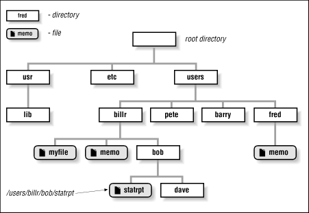

## Directories

You can check your working directory anytime using `getwd()`:

```r
getwd()
```

```
## [1] "/Users/brookeanderson/Desktop/ChinaCDCRWorkshop/ChinaCourseMaterials"
```

## Directories

You can use `setwd()` to change your directory.

To get to your home directory (for example, mine is "/Users/brookeanderson"), you can use the abbreviation `~`.

For example, if you want to change into your home directory and print its name, you could run:

```r
setwd("~")
getwd()
```

```
## [1] "/Users/brookeanderson"
```

## Directories

The most straightforward way to read in data is often to put it in your working directory and then read it in using the file name. If you're working in the directory with the file you want, you should see the file if you list files in the working directory:

```r
list.files()
```

```
##  [1] "ChinaCourseMaterials.Rproj" "CourseNotes_1.html"
##  [3] "CourseNotes_1.Rmd"          "CourseNotes_2.html"
##  [5] "CourseNotes_2.Rmd"          "CourseNotes_3.html"
##  [7] "CourseNotes_3.Rmd"          "data"
##  [9] "figures"                    "InCourseExercise_1.html"
## [11] "InCourseExercise_1.Rmd"     "InCourseExercise_2.html"
## [13] "InCourseExercise_2.Rmd"     "quizzes"
```

## Directories

If you want to list files in another directory, you can use an absolute or relative pathname to do that. For example, to list the files in the "data" subdirectory of my current directory, I would run:

```r
list.files("data")
```

```
## [1] "country_timeseries.csv"  "daily_show_guests.csv"
## [3] "deaths-weather.csv"      "icd-10.xls"
## [5] "ICU_Data_Code_Sheet.pdf" "icu.sas7bdat"
## [7] "ld_genetics.txt"         "measles_data"
```

## Getting around directories

There are a few abbreviations you can use to represent certain relative or absolute locations when you're using `setwd()`:

| Command | Directory |
| --- | --- |
| `setwd("~")` | Your home directory |
| `setwd("..")` | One directory up from your current directory |
| `setwd("../..")` | Two directories up from your current directory |

## Taking advantage of `paste0`

You can create an object with your directory name using `paste0`, and then use that to set your directory. We'll take a lot of advantage of this for reading in files.

The convention for `paste0` is:

```r
[object name] <- paste0("[first thing you want to paste]",
                        "[what you want to add to that]",
                        "[more you want to add]")
```

## Taking advantage of `paste0`

Here's an example:

```r
my_dir <- paste0("~/Desktop/ChinaCDCRWorkshop/",
                 "ChinaCourseMaterials/data")
my_dir
```

```
## [1] "~/Desktop/ChinaCDCRWorkshop/ChinaCourseMaterials/data"
```

```r
setwd(my_dir)
```

## Relative versus absolute pathnames

When you want to reference a directory or file, you can use one of two types of pathnames:

- *Relative*: How to get there from your current working directory
- *Absolute*: The full pathname

## Relative versus absolute pathnames

Say your current working directory was `/Users/brookeanderson/Desktop/ChinaCDCRWorkshop` and you wanted to get into the subdirectory `ChinaCourseMaterials`. Here are examples using the two types of pathnames:

Absolute:

```r
setwd("/Users/brookeanderson/Desktop/ChinaCDCRWorkshop/ChinaCourseMaterials")
```

Relative:

```r
setwd("ChinaCourseMaterials")
```

## Relative versus absolute pathnames

Here are some other examples of relative pathnames:

If `ChinaCourseMaterials` is a subdirectory of your current parent directory:

```r
setwd("../ChinaCourseMaterials")
```

If `ChinaCourseMaterials` is a subdirectory of your home directory:

```r
setwd("~/ChinaCourseMaterials")
```

If `ChinaCourseMaterials` is a subdirectory of the subdirectory `Ex` of your current working directory:

```r
setwd("Ex/ChinaCourseMaterials")
```

## Reading data into R

## What kind of data can you get into R?

The sky is the limit…

- Flat files
- Files from other statistical packages (SAS, Excel, Stata, SPSS)
- [Tables on webpages](http://yihui.name/en/2010/10/grabbing-tables-in-webpages-using-the-xml-package/) (e.g., the table near the end of [this page](http://en.wikipedia.org/wiki/Ebola_virus_epidemic_in_West_Africa))
- Data in a database (e.g., SQL)
- Really crazy data formats used in other disciplines (e.g., [netCDF files from climate folks](https://www.image.ucar.edu/GSP/Software/Netcdf/), [MRI data stored in Analyze, NIfTI, and DICOM formats](http://www.tractor-mri.org.uk))
- Data through APIs (e.g., [GoogleMaps](http://www.r-bloggers.com/heatmap-of-toronto-traffic-signals-using-rgooglemaps/), [Twitter](http://davetang.org/muse/2013/04/06/using-the-r_twitter-package/))
- Incrediably messy data using `scan` and `readLines`

## Types of flat files

R can read in data from *a lot* of different formats. The only catch: you need to tell R how to do it.

To start, we'll look at flat files:

1. Fixed width files
2. Delimited files
- ".csv": Comma-separated values
- ".tab", ".tsv": Tab-separated values
- Other possible delimiters: colon, semicolon, pipe ("|")

See if you can identify what types of files the following files are…

## What type of file?

[figure not shown]

## What type of file?

[figure not shown]

## What type of file?

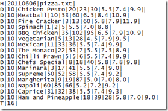

## What type of file?

[figure not shown]

## What type of file?

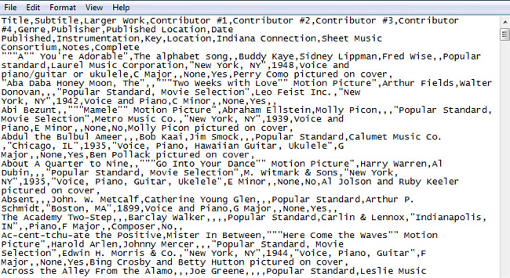

## What type of file?

[figure not shown]

## What type of file?

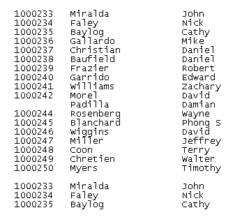

## Reading in flat files

R can read any of these types of files using one of the `read.table` and `read.fwf` functions. Find out more about those functions with:

```r
?read.table
?read.fwf
```

## `read.table` family of functions

Some of the interesting options with the `read.table` family of functions are:

| Option | Description |
| --- | --- |
| `sep` | What is the delimiter in the data? |
| `skip` | How many lines of the start of the file should you skip? |
| `header` | Does the first line you read give column names? |
| `as.is` | Should you bring in strings as characters, not factors? |
| `nrows` | How many rows do you want to read in? |
| `na.strings` | How are missing values coded? |

## `read.table` family of functions

All members of the `read.table` family are doing the same basic thing. The only difference is what defaults they have for the separator (`sep`) and the decimal point (`dec`).

Members of the `read.table` family:

| Function | Separator | Decimal point |
| --- | --- | --- |
| `read.csv` | comma | period |
| `read.csv2` | semi-colon | comma |
| `read.delim` | tab | period |
| `read.delim2` | tab | comma |

## Reading in online flat files

If you're reading in data from a non-secure webpage (i.e., one that starts with `http`), if the data is in a "flat-file" format, you can just read it in using the [web address](http://www2.unil.ch/comparativegenometrics/docs/NC_006368.txt) as the file name:

```r
url <- paste0("http://www2.unil.ch/comparativegenometrics",
              "/docs/NC_006368.txt")
ld_genetics <- read.delim(url, header = TRUE)
```

## Reading in online flat files

If you want to read in data from a secure webpage (e.g., one that starts with `https`), then you'll need to do something different.

First, you'll need to install then load the package `repmis`:

```r
# install.packages("repmis")
library(repmis)
```

## Reading in online flat files

```r
url <- paste0("https://raw.githubusercontent.com/cmrivers/",
              "ebola/master/country_timeseries.csv")
ebola <- source_data(url)
```

## Cleaning up data in R

## Renaming columns

Often, you'll want to change the column names of a dataframe as soon as you bring in the data, especially if the original ones have things like spaces. We'll look at this in the `icd10` data.

```r
library(readxl)
icd10 <- read_excel("data/icd-10.xls")
```

[output not shown]

## Renaming columns

Take a look at the `icd10` data we loaded in the exercise:

```r
icd10[1:4, ]
```

```
##      Code                                          ICD Title
## 1 A00-B99       I. Certain infectious and parasitic diseases
## 2 A00-A09                     Intestinal infectious diseases
## 3     A00                                            Cholera
## 4   A00.0 Cholera due to Vibrio cholerae 01, biovar cholerae
```

## Renaming columns

You can use the `colnames()` function to find out what the current column names are:

```r
colnames(icd10)
```

```
## [1] "Code"      "ICD Title"
```

## Renaming columns

```r
colnames(icd10) <- c("code", "title")
icd10[1:2, ]
```

```
##      code                                        title
## 1 A00-B99 I. Certain infectious and parasitic diseases
## 2 A00-A09               Intestinal infectious diseases
```

## Using `subset()`

You will often want to use only a portion of your data. You can use `subset()` to create a subset, using logical operators. For example, if you wanted to just pull out the rows of the `icd10` dataframe that start with the letter "A", you could run:

```r
icd10_a <- subset(icd10, substr(code, 1, 1) == "A")
```

## Using `subset()`

Here are the ends of the original and the subsetted dataframes:

```r
tail(icd10, 2)
```

```
##        code                                  title
## 11089 Y89.9 Sequelae of unspecified external cause
## 11090  <NA>                                   <NA>
```

```r
tail(icd10_a, 2)
```

```
##      code                                    title
## 458 A98.8 Other specified viral hemorrhagic fevers
## 459   A99      Unspecified viral hemorrhagic fever
```

## Using `subset()`

The convention for `subset()` is:

```r
subset([name of dataframe],
       [logical statement describing which rows to keep],
       select = [vector with the names of columns to keep])
```

## Common logical operators in R

| Operator | Meaning | Example |
| --- | --- | --- |
| `==` | equals | `subset(df, city == "Los Angeles")` |
| `!=` | does not equal | `subset(df, city != "Los Angeles")` |
| `%in%` | is in | `subset(df, city %in% c("Los Angeles", "San Diego"))` |
| `is.na()` | is NA | `subset(df, is.na(cases))` |
| `!is.na()` | is not NA | `subset(df, !is.na(cases))` |
| `&` | and | `subset(df, city == "Los Angeles" & !is.na(cases))` |
| `\|` | or | `subset(df, city == "Los Angeles" \| !is.na(cases))` |

## Adding columns

In R, you can use the `$` operator after a dataframe to pull out one of it's columns. For example:

```r
ca_measles <- read.delim("data/measles_data/02-09-2015.txt",
                         header = FALSE,
                         col.names = c("city", "count"))
head(ca_measles$count)
```

```
## [1]  6 20  2  4  2 34
```

## Adding columns

You can take advantage of this to add new columns to an existing dataframe. For example, this data is from Feb. 9, 2015. We can add a column with the date to `ca_measles`:

```r
ca_measles$date <- rep("02-09-2015", length = nrow(ca_measles))
head(ca_measles, 3)
```

```
##                 city count       date
## 1            ALAMEDA     6 02-09-2015
## 2        LOS ANGELES    20 02-09-2015
## 3 City of Long Beach     2 02-09-2015
```

## Adding columns

Two notes:

- The previous example uses the `rep()` function, which will repeat a value `length` number of times
- If the value you assign to the new column is not the right length (remember, all columns in a dataframe must be vectors of equal length), R will try to "recycle" it to fill up the dataframe. So, the following call would have been a simpler alternative:

```r
ca_measles$date <- "02-09-2015"
ca_measles[1:2, ]
```

```
##          city count       date
## 1     ALAMEDA     6 02-09-2015
## 2 LOS ANGELES    20 02-09-2015
```

## `Date` class

One final common task in cleaning data is to change the class of some of the columns. This is especially common for dates, which will usually be read in as characters or factors.

## Vector classes

Here are a few common vector classes in R:

| Class | Example |
| --- | --- |
| `character` | "Chemistry", "Physics", "Mathematics" |
| `numeric` | 10, 20, 30, 40 |
| `factor` | Male [underlying number: 1], Female [2] |
| `Date` | "2010-01-01" [underlying number: 14,610] |
| `logical` | TRUE, FALSE |

## Vector classes

To find out the class of a vector, you can use `class()`:

```r
class(ca_measles$date)
```

```
## [1] "character"
```

## Vector classes

To find out the classes of all columns in a dataframe, you can use `str()`:

```r
str(ca_measles)
```

```
## 'data.frame':    13 obs. of  3 variables:
##  $ city : Factor w/ 13 levels "ALAMEDA","City of Long Beach",..: 1 4 2 3 5 6 7 8 9 10 ...
##  $ count: int  6 20 2 4 2 34 5 6 13 3 ...
##  $ date : chr  "02-09-2015" "02-09-2015" "02-09-2015" "02-09-2015" ...
```

## Converting to `Date` class

To convert a vector to the `Date` class, you can use `as.Date()`:

```r
ca_measles$date <- as.Date(ca_measles$date,
                           format = "%m-%d-%Y")
head(ca_measles$date, 3)
```

```
## [1] "2015-02-09" "2015-02-09" "2015-02-09"
```

```r
class(ca_measles$date)
```

```
## [1] "Date"
```

## Converting to `Date` class

Once you have an object in the `Date` class, you can do things like plot by date, calculate the range of dates, and calculate the total number of days the dataset covers:

```r
range(ca_measles$date)
```

```
## [1] "2015-02-09" "2015-02-09"
```

```r
diff(range(ca_measles$date))
```

```
## Time difference of 0 days
```

## Converting to `Date` class

The only tricky thing is learning the abbreviations for the `format` option. Here are some common ones:

| Abbreviation | Meaning |
| --- | --- |
| `%m` | Month as a number (e.g., 1, 05) |
| `%B` | Full month name (e.g., August) |
| `%b` | Abbreviated month name (e.g., Aug) |
| `%y` | Two-digit year (e.g., 99) |
| `%Y` | Four-digit year (e.g., 1999) |

## Converting to `Date` class

Here are some examples:

| Your date | `format =` |
| --- | --- |
| 10/23/2008 | "%m/%d%Y" |
| 08-10-23 | "%y-%m-%d" |
| Oct. 23 2008 | "%b. %d %Y" |
| October 23, 2008 | "%B %d, %Y" |